# Theory Assignment - Residuals, Sum of Squares and R-quared

May 1, 2019

## Residuals

#### What is a residual? What use does a single residual provide within a regression analysis?

- A residual is the difference between the observed Y-value and the predicted Y-value. A single residual tells us how far off a single point is from the average. For example, in the plot below, the red point indicates a laptop priced well above the average for other laptops with the same amount of RAM.

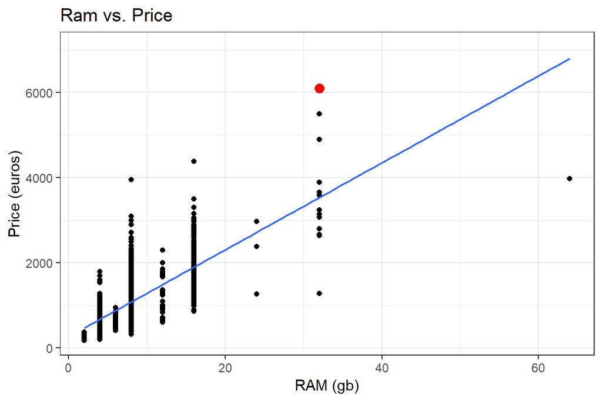

```r
laptops %>%
  ggplot(aes(x = ram_gb, y = Price_euros)) +
  geom_point() +
  geom_lm() +
  geom_point(aes(x = 32, y = 6099.00), color = "Red", size = 3) +
  labs(x = "RAM (gb)", y = "Price (euros)", title = "Ram vs. Price") +
  theme_bw()
```

## SSTO, SSR, SSE

#### What are each of SSTO, SSR, and SSE? How are they related? How do they differ? Find a way to both show and explain these values. How are they used to gain insight about data within a regression analysis?

- SSTO: The difference between each individual Y-value and the average Y-value.
- SSR: The difference between the predicted Y-value and the average Y-value.
- SSE: The difference between each individual Y-value and the predicted Y-value.
- The SSE and the SSR have an inverse relationship in that as one increases, the other decreases. The sum of the SSE and the SSR is equal to the SSTO.
- Each differs in what it tells us about the data. The SSTO can tell us how much each Y-value differs from one another in relation to the average. The SSR tells us how much our predictive model differs from the average of all the Y-values. The SSE tells us how much each Y-value differs from our predictive model.

## $R^2$

#### What is R-squared? How is it properly interpreted? How is it calculated? What information does it provide about a regression analysis? How does it differ from the information provided in the p-value for the slope term? How does it relate to the residual standard error?

- The $R^2$ value is the correlation coefficient. It is interpreted as the proportion of the variability that can be explained by the regression model. $R^2$ is calculated by dividing the SSR by the SSTO. This tells us how well our model fits the rest of our data. The p-value for the slope term tells us whether our results are significant while the $R^2$ tells us about the ability of our model to make predictions. Since the $R^2$ value is calculated using the ratio between the SSR and SSTO, we usually want a high $R^2$ value. This means that we want a low SSE since the SSR and SSE react inversely to one another.